# Project One

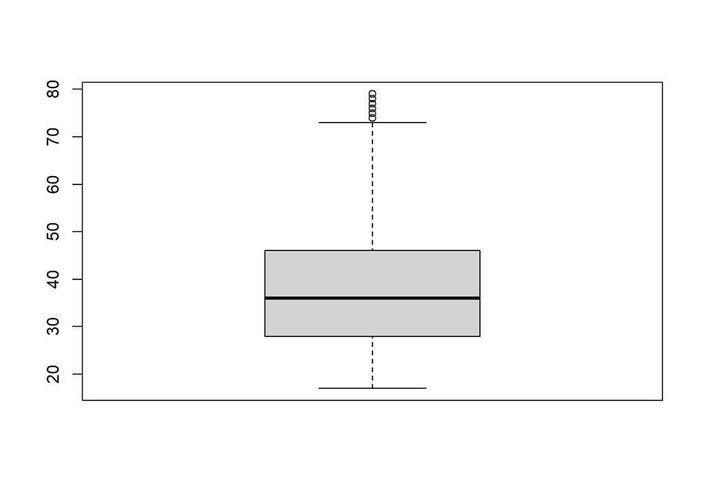

```r
boxplot(df$AgeUSdriving_1,bins=20)
```

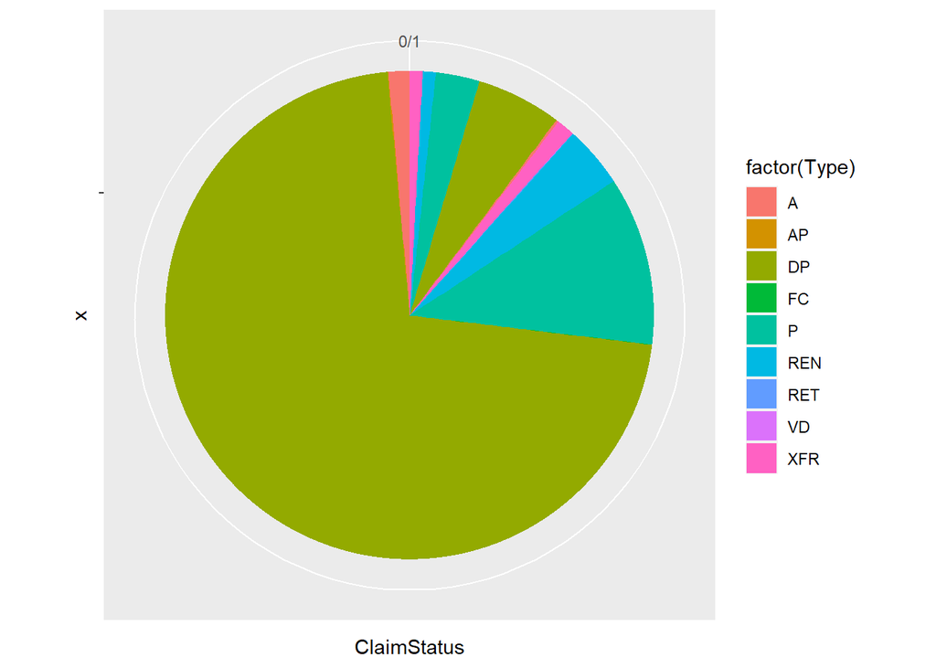

```r
#we plot the barplot of the ClaimStatus count and see the types, this would be a pie plot by keeping the coord_polar() arguments
ggplot(df, aes(x="", y=ClaimStatus, fill=factor(Type))) +geom_bar(stat="identity", width=1) +coord_polar("y", start=0)
```

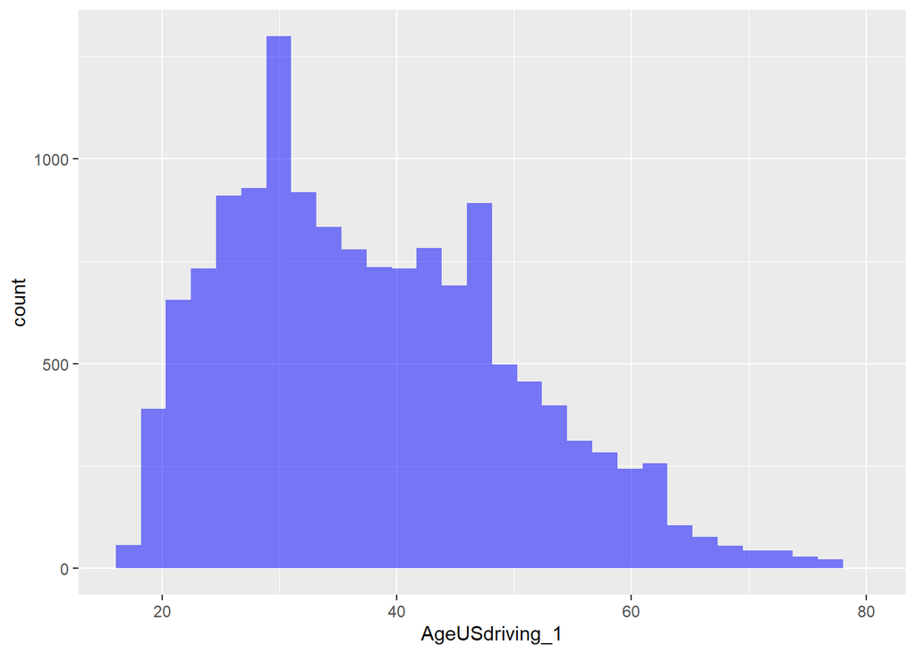

```r
#check the histogram the dustribution of the age
ggplot(df,aes(AgeUSdriving_1)) + geom_histogram(fill='blue',bins=30,alpha=0.5)
```

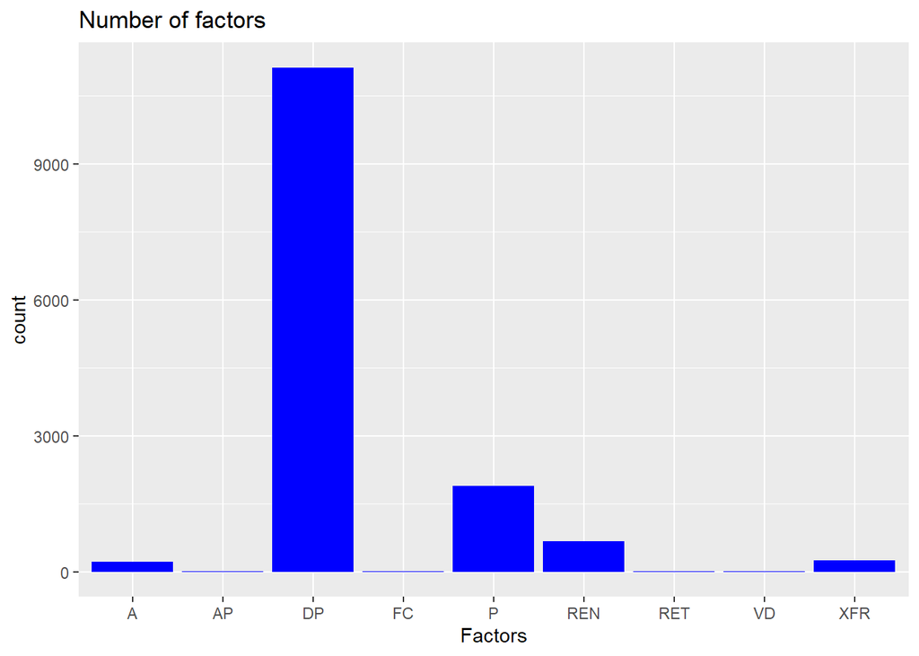

```r
#next we plot the geom_bar to see the Type and their count
ggplot(data = df) +geom_bar(mapping = aes(x = factor(Type)),fill="blue")+xlab("Factors")+ggtitle("Number of factors")
```

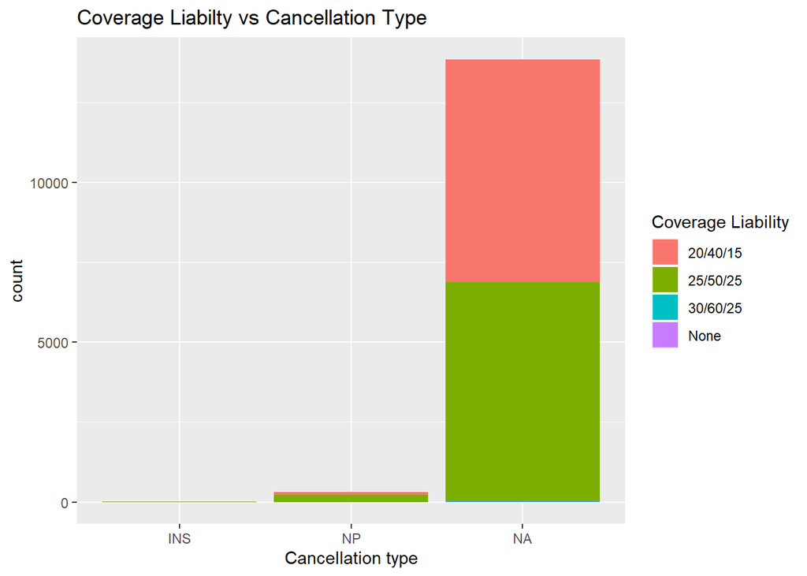

```r
#we see the barplots to see the count of CancellationType by the CoverageLiability of a customer
ggplot(data = df) +geom_bar(mapping = aes(x = factor(CancellationType),fill=factor(CoverageLiability)))+xlab("Cancellation type")+labs(fill="Coverage Liability",title="Coverage Liabilty vs Cancellation Type")
```

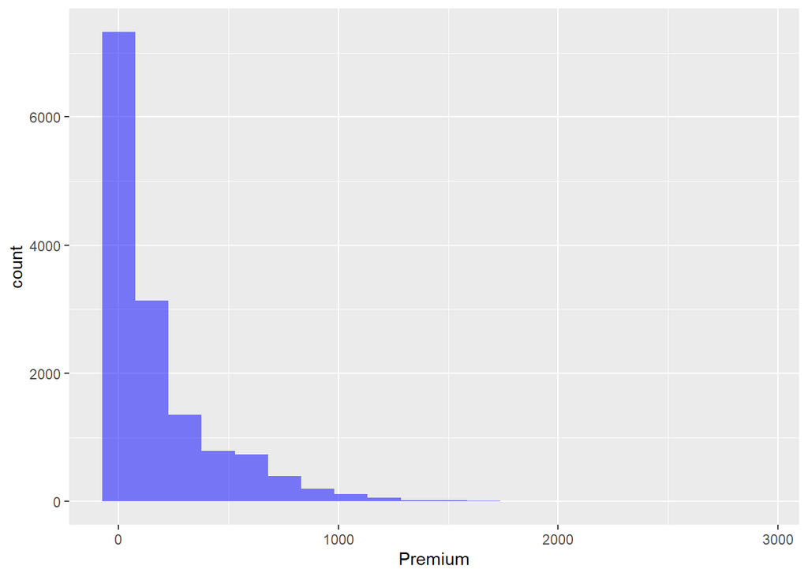

```r
ggplot(df,aes(Premium)) + geom_histogram(fill='blue',bins=20,alpha=0.5)# Premium is not noramlized, we have to do it later
```

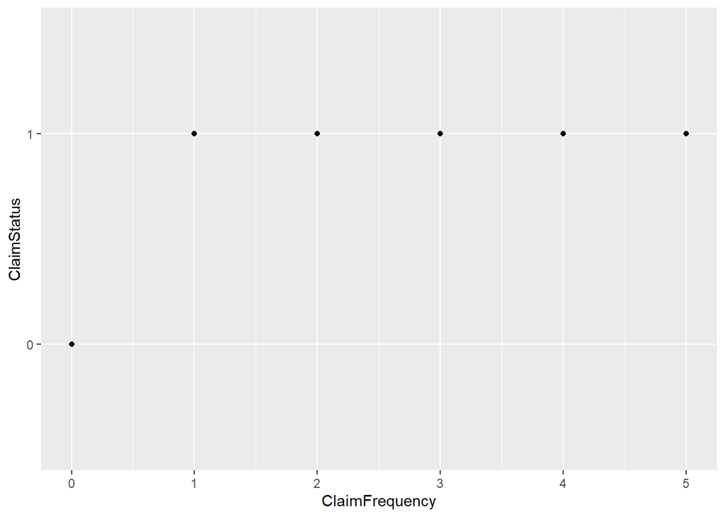

```r
ggplot(df,aes(x=ClaimFrequency,y=ClaimStatus))+geom_point()
```

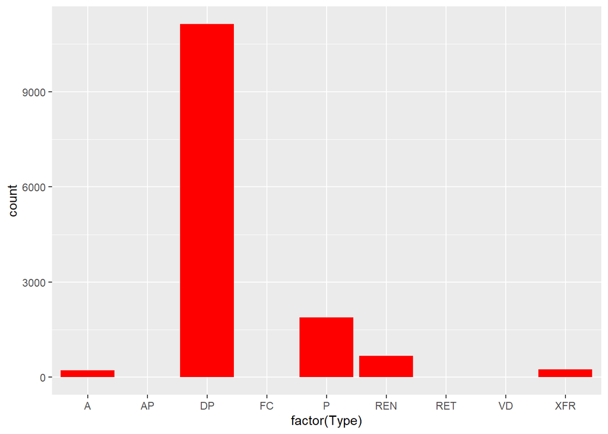

```r
ggplot(data = df) +geom_bar(mapping = aes(x = factor(Type)),fill="red")
```

# Preprocessing

As stated earlier the data has a lot of missing values which needs to be treated so that our model can be trained on the data and then the conclusion can be drawn from the data. The categorical variables are replaced by the mode of that variable. The numerical variables are replaced by their mean. The algorithms like random forest needs the input data to be in the numerical formats, so the categorical variables are converted to their equivalent numerical aliases using the Label Encoding. The data is also normalized by using Min Max Scaler.

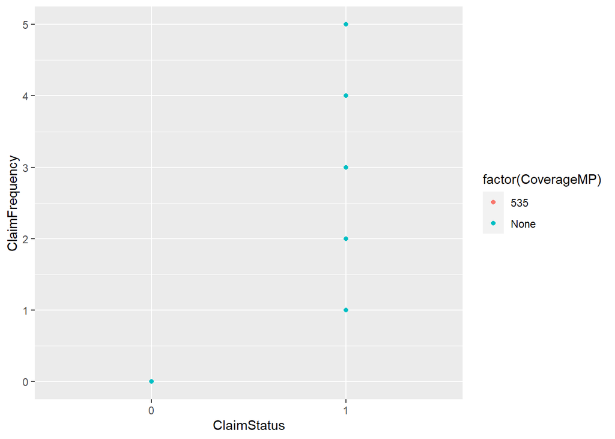

```r
#this function is used to find the unique values and then compute the mode (the most occuring values in  adata and would be used to impute the missing values)
getmode <- function(x) {
  uniqv <- unique(x)
  uniqv[which.max(tabulate(match(x, uniqv)))]
}


# Calculate the mode using the user function and then save the values inplace of missing values
result.most.age <- getmode(df$AgeUSdriving_1) #Most common age in 28
result.most.gender <- getmode(df$Sex_1) #Most of the drivers are male

# Filling in the missing values
df$Model_1[is.na(df$Model_1)] <-getmode(df$Model_1)
# df$Make_1[is.na(df$Make_1)] <-getmode(df$Make_1)

# df$CoverageLiability[is.na(df$CoverageLiability)] <-getmode(df$CoverageLiability)

df$CoverageMP[is.na(df$CoverageMP)] <-getmode(df$CoverageMP)
df$CoveragePD_1[is.na(df$CoveragePD_1)] <-getmode(df$CoveragePD_1)
df$CoveragePIP_CDW[is.na(df$CoveragePIP_CDW)] <-getmode(df$CoveragePIP_CDW)
df$CoverageUMBI[is.na(df$CoverageUMBI)] <-getmode(df$CoverageUMBI)
df$CoverageUMPD[is.na(df$CoverageUMPD)] <-getmode(df$CoverageUMPD)


#only

p <- ggplot(df, aes(ClaimStatus, ClaimFrequency))
p + geom_point(aes(colour=factor(CoverageMP)))
```

```r
#convert the values to factors so that we can have classes
#the logic is to first get the unqiue values and convert to list
#Next is to take the one elemet less than the length because the encoded values
#are starting from zero
#in the factor argument the labels represnts the labels required

list.of.make.1 <- as.list(unique(df$Type))
length.of.make1 <- (length(list.of.make.1)-1)
df$Type<- factor(df$Type,levels = list.of.make.1,labels =c(0:8))

#
list.of.make.1 <- as.list(unique(df$CoverageLiability))
length.of.make1 <- (length(list.of.make.1)-1)
df$CoverageLiability <- factor(df$CoverageLiability,levels = list.of.make.1,labels =c(0:3))

list.of.make.1 <- as.list(unique(df$Model_1))
length.of.make1 <- (length(list.of.make.1)-1)
df$Model_1 <- factor(df$Model_1,levels = list.of.make.1,labels =c(0:1447)) #ONEHOT
#
list.of.make.1 <- as.list(unique(df$CoverageMP))
length.of.make1 <- (length(list.of.make.1)-1)
df$CoverageMP <- factor(df$CoverageMP,levels = list.of.make.1,labels = c(1:2))

#

#
list.of.make.1 <- as.list(unique(df$CoveragePD_1))
length.of.make1 <- (length(list.of.make.1)-1)
df$CoveragePD_1 <- factor(df$CoveragePD_1 ,levels = list.of.make.1,labels = c(1:3))
#
list.of.make.1 <- as.list(unique(df$CoveragePIP_CDW))
length.of.make1 <- (length(list.of.make.1)-1)
df$CoveragePIP_CDW <- factor(df$CoveragePIP_CDW ,levels = list.of.make.1,labels = c(1:3))
#

#

#

#here we replace the continous values by the MinMaxScaler so that every value is on the same scale

df$Premium <- (df$Premium-min(df$Premium))/(max(df$Premium) - min(df$Premium))
df$ClaimFrequency <- (df$ClaimFrequency-min(df$ClaimFrequency))/(max(df$ClaimFrequency) - min(df$ClaimFrequency))
df$VehicleInspected_1 <- (df$VehicleInspected_1-min(df$VehicleInspected_1))/(max(df$VehicleInspected_1) - min(df$VehicleInspected_1))
df$Units <- (df$Units-min(df$Units))/(max(df$Units) - min(df$Units))
df$Billing_Term <- (df$Billing_Term-min(df$Billing_Term))/(max(df$Billing_Term) - min(df$Billing_Term))
df$Renewed <- (df$Renewed-min(df$Renewed))/(max(df$Renewed) - min(df$Renewed))
df$Amendment <- (df$Amendment-min(df$Amendment))/(max(df$Amendment) - min(df$Amendment))

df$VehicleInspected_1 <-(df$VehicleInspected_1-min(df$VehicleInspected_1))/(max(df$VehicleInspected_1) - min(df$VehicleInspected_1))






#We can see that only few attributes have larger affect on the claimstatus,
#So we have to drop those irreveleant columns
# 88:89,91:119,120,123,1
```